# Reproducible Research: Assignment 1

# Loading and preprocessing the data

First of all, I loaded csv file using read.csv. After that, some rows are showed.

```r
d <- read.csv('activity.csv')
```

## basic structure

It shows basic structure of this data file.

```r
head(d)
```

```
##   steps       date interval
## 1    NA 2012-10-01        0
## 2    NA 2012-10-01        5
## 3    NA 2012-10-01       10
## 4    NA 2012-10-01       15
## 5    NA 2012-10-01       20
## 6    NA 2012-10-01       25
```

```r
summary(d)
```

```
##      steps                date          interval
##  Min.   :  0.00   2012-10-01:  288   Min.   :   0.0
##  1st Qu.:  0.00   2012-10-02:  288   1st Qu.: 588.8
##  Median :  0.00   2012-10-03:  288   Median :1177.5
##  Mean   : 37.38   2012-10-04:  288   Mean   :1177.5
##  3rd Qu.: 12.00   2012-10-05:  288   3rd Qu.:1766.2
##  Max.   :806.00   2012-10-06:  288   Max.   :2355.0
##  NA's   :2304     (Other)   :15840
```

```r
nrow(d)
```

```
## [1] 17568
```

# What is mean total number of steps taken per day?

ddply is used to get the number of total steps for each day. mean value can be gotten through dividing the number of stpes by the number of days.  
median value can be showed by getting median value after sorting.

median/mean functions are used for getting values simply.

```r
library(plyr)
out <- ddply(d, c("date"),summarize, steps=sum(steps))

mean_val <-mean(out$steps, na.rm = T)
median_val <- median(out$steps, na.rm=T)

mean_val
```

```
## [1] 10766.19
```

```r
median_val
```

```
## [1] 10765
```

```r
head(out)
```

```
##         date steps
## 1 2012-10-01    NA
## 2 2012-10-02   126
## 3 2012-10-03 11352
## 4 2012-10-04 12116
## 5 2012-10-05 13294
## 6 2012-10-06 15420
```

## histogram

The output graph is saved in plot0.png file.

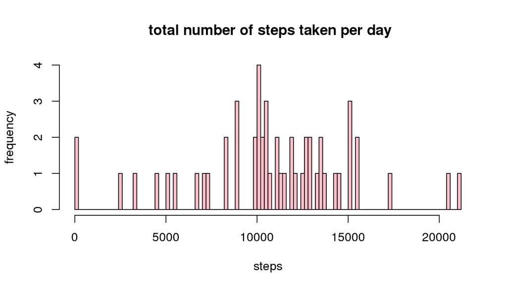

```r
hist(out$steps ,breaks=100, main=" total number of steps taken per day",
     xlab="steps", ylab="frequency", col="pink")
```

```r
dev.copy(png,'plot0.png')
```

```r
dev.off()
```

# What is the average daily activity pattern?

1 day has 24 hours. 1 hour has 60 minutes. Therefore 2460 means minutes of a day.  
2460 is divided by 5 because they made data every 5 minutes. As a result, total number of interval count is 288 (24*60/5).  
“for loop”" is used to get average values for each time interval.  
For example, mean(first row of d + 289th row + 577th row ….. 16993th row + 17281th row) is the average steps value of first interval.

out2 is used for saving the mean value for each interval.

```r
days <- nrow(out)
interval_cnt <- 24*60/5

out2 <- rep(0, interval_cnt)

for(i in 1:interval_cnt)
{
    some <- seq(i, nrow(d), by= interval_cnt)
    out2[i] <- mean( d[some,]$steps, na.rm=T)
}
```

## Plot it.

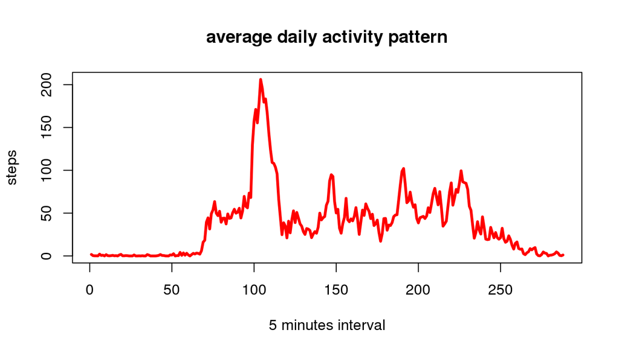

```r
plot(out2 , type="l", main="average daily activity pattern",
     xlab="5 minutes interval",ylab="steps", col="red" , lwd=3)
```

```r
dev.copy(png,'plot1.png')
```

```r
dev.off()
```

## maximum active interval value

```r
max_interval <- max(out2)
print(max_interval)
```

```
## [1] 206.1698
```

# Imputing missing values

set the missing value to the average. out2 is the daily activity pattern.  
As calculated before, 288(24*60/5) is interval count of a day.

```r
d_imputed <- d
for(i in 1:nrow(d_imputed) )
{
    if( is.na(d_imputed[i,1])  == TRUE)
    {
       d_imputed[i,1] <- out2[ i %% 288 + 1]

    }
}

out4hist <- ddply(d_imputed, c("date"),summarize, steps=sum(steps))
```

## histogram

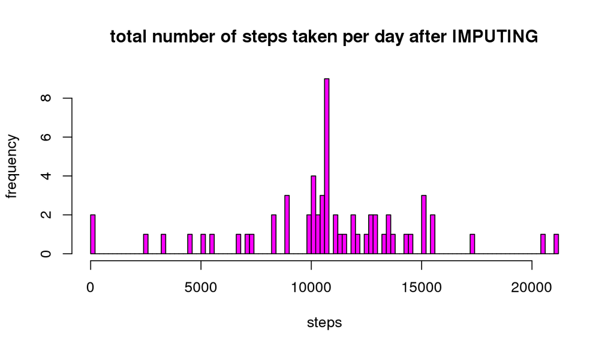

```r
hist(out4hist$steps ,breaks=100,
     main="total number of steps taken per day after IMPUTING" , xlab="steps",ylab="frequency", col="magenta")
```

```r
dev.copy(png,'plot2.png')
```

```r
dev.off()
```

# Are there differences in activity patterns between weekdays and weekends?

As we expected, peopel tend to move more on the weekend. I’ll calculate the average value of steps on the weekdays/weekends.

I found timeDate package after struggling from identifying weekend.

weekdays_n : the number of weekdays  
weekdays_sum: total number of steps on weekdays.

weekend_n : the number of weekend.  
weekend_sum: total number of steps on weekend.

```r
#install.packages("timeDate")
library(timeDate)

out3 <- ddply(d_imputed, c("date"),summarize, steps=sum(steps))


weekdays_n <- 0
weekdays_sum <-0

weekend_n <- 0
weekend_sum <- 0


for(i in 1:nrow(out3))
{
    if( as.logical(isWeekend(as.Date(out3[i,1]), wday = 1:5)) )
    {
       weekend_n <- weekend_n +1
       weekend_sum <- weekend_sum + out3[i,2]

    }
    else
    {
       weekdays_n <- weekdays_n + 1
       weekdays_sum <- weekdays_sum + out3[i,2]

    }
}
```

## print average steps in weekend & weekdays

As expected, people walk more on weekends compared to weekdays.

```r
print( weekend_sum / weekend_n )
```

```
## [1] 12201.52
```

```r
print( weekdays_sum / weekdays_n )
```

```
## [1] 10255.85
```

## weekdays vs weekends with plotting

24*60/5 means the number of interval count per a day. I calculated above.

idx: index for weekdays_arr, weekends_arr

```r
interval_cnt <- 24*60/5
weekdays_arr<- rep(0, interval_cnt)
weekends_arr <- rep(0,interval_cnt)

for(i in 1:nrow(d_imputed) )
{
    steps    = d_imputed[i,1]
    date     = d_imputed[i,2]
    idx      = d_imputed[i,3]/5

    if( as.logical(isWeekend(as.Date(date), wday = 1:5)) )
    {
        weekdays_arr[idx] <- weekdays_arr[idx] + steps

    }
    else
    {
        weekends_arr[idx] <- weekends_arr[idx] + steps
    }

}
```

[figure not shown]

```r
plot(weekdays_arr , type="l", main="weekdays activity pattern",
     xlab="5 minutes interval",ylab="steps", col="blue" , lwd=3)
```

```r
dev.copy(png,'plot3.png')
```

```r
dev.off()
```

[figure not shown]

```r
plot(weekends_arr , type="l", main="weekends activity pattern",
     xlab="5 minutes interval",ylab="steps", col="blue" , lwd=3)
```

```r
dev.copy(png,'plot4.png')
```

```r
dev.off()
```